# 02_codrone_basic

# 4. Sensors

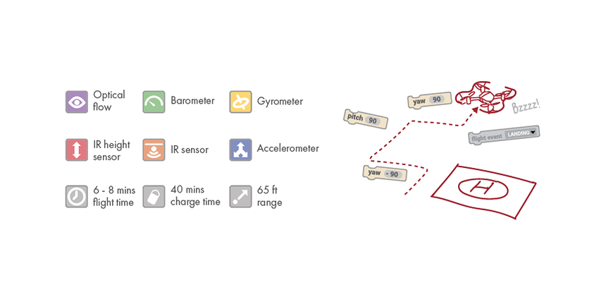

## 4.1. Drone State

This function gets the state of the drone, as in whether it’s: ready, takeoff, flight, flip, stop, landing, reverse, accident, error.

```python
# take off the drone if state is not on flight
state = drone.get_state()
if state != "FLIGHT":
    drone.takeoff()

drone.hover(3)
drone.land()
```

## 4.2. Optical Flow Sensor

This function gets the $x$ and $y$ coordinates from the optical flow sensor. Keep in mind, the positioning does not take rotation into account.

```python
# print the optical flow position x,y value
position = drone.get_opt_flow_position()
print(position.X, position.Y)
```

## 4.3. Battery Voltage

This function gets the voltage of the battery.

```python
# print the battery voltage of drone.
battery = drone.get_battery_voltage()
print(battery)
```

## 4.4. Temperature

This is a getter function gets the data from the drone’s temperature sensor. Importantly, it reads the drone’s temperature, not the air around it.

```python
# print the temperature of drone
temperature = drone.get_drone_temp()
print(temperature)
```

## 4.5. Pressure

This is a getter function gets the data from the barometer sensor.

```python
# print the pressure
pressure = drone.get_pressure()
print(pressure)
```

## 4.6. Trim

This function gets the current trim values of the drone.

```python
#print current drone's trim value
trim = drone.get_trim()
print(trim.ROLL, trim.PITCH, trim.YAW, trim.THROTTLE)
```

## 4.7. Height

This is a getter function gets the current height of the drone from the object directly below its IR sensor.

```python
drone.takeoff()

for i in range(100):
    height = drone.get_height()
    print(height)
    if height < 1000:
        drone.go(Direction.UP)
    elif height > 1000:
        break
drone.hover(2)

drone.land()
```

## 4.8. Accelerometer

This function gets the accelerometer sensor data, which returns $x$, $y$, and $z$ values in $m/s^2$. It outputs to the UI in Blockly and as a class in Python as a struct in Arduino.

```python
# print the acceleration of drone
acceleration = drone.get_accelerometer()
print(acceleration.X, acceleration.Y, acceleration.Z)
```

## 4.9. Gyro Sensor

This function gets the data from the gyrometer sensor to determine the roll, pitch, and yaw as angles.

```python
# print the angles of drone
GyroAngles = drone.get_gyro_angles()
print(GyroAngles.ROLL, GyroAngles.PITCH, GyroAngles.YAW)
```

## 4.10. Battery

This function gets the battery percentage of the drone, returning a value from 0 to 100.

```python
drone.takeoff()

# stop the drone if battery is lower than 10 percent.
battery = drone.get_battery_percentage()
if battery < 10:
    drone.emergency_stop()
```

```python
%%javascript

$.getScript('https://kmahelona.github.io/ipython_notebook_goodies/ipython_notebook_toc.js')
```